# Carreras Deportivas en España

# Carreras deportivas en España en 2019

Autores: Eugenio Carmona Soriano y Antonio Ruíz Falcó Rojas

Mayo 2019

# 1 Descripción del DataSet.

El conjunto de datos utilizado en esta actividad es el generado en la primera práctica mediante web scraping, y recoge los eventos de carreras deportivas que se realizan en España el año 2019. Las variables que se recogen en el conjunto de datos son la fecha, el nombre, el lugar, el tipo de carrera, la distancia, la página web de la carrera y si incluye categorías infantiles.

Para cada carrera, se crea un registro en el conjunto de datos que recogen los siguientes campos para todo el año 2019:

- **Fecha**: el día en el que se realiza la carrera en formato dd/mm/aaaa.
- **Carrera**: Nombre de la carrera.
- **Ciudad**: Ciudad en la que se realiza la carrera.
- **Provincia**: Provincia en la que se realiza la carrera.
- **Tipo**: Tipo de carrera. Ruta, Trail, Triatlón, Ciclismo, Duatlón, Obstáculos y Cross/Tierra.
- **Distancia**: La distancia a recorrer en la carrera:
- **Web**: Enlace a la página web de la carrera.
- **Infantil**: Si o No. Según incluya o no categorías infantiles.

Los datos son importantes, pues el conjunto de datos se corresponde con las competiciones deportivas, más concretamente carreras deportivas, que se realizan en España el año 2019. Se incluyen varios tipos de carreras entre los que encuentran: Rutas, Trails, Triatlón, Ciclismo, Duatlón, Obstáculos y Cross/Tierra.

La página web elegida para obtener la información la ofrece a titulo informativo a todo aquel que quiera conocer las diferentes competiciones que se realizan, el lugar y la fecha. Además de ofrecer el enlace a la página web oficial de cada carrera.

Es evidente que el *footing* o *running* es la actividad física básica. El estudio de los datos permitirá adquirir conocimiento sobre la práctica de deporte popular. Por ejemplo, permitirá estudiar si la actividad física cambia de unas regiones a otras, la distribución de pruebas a lo largo del año, diferenciación entre las competiciones de niños y adultos, etc. En el presente trabajo se realizarán los siguientes estudios:

- Detección de las **reglas de asociación** entre mes de la prueba, provincia de la prueba, tipo de carrera, distancia y si es infantil o no.
- Detección de grupos mediante **Árboles de decisión** para los campos anteriores.
- Estudio de **regresión múltiple**.

# 2 Datos de Interés.

En el apartado anterior se ha mostrado que el conjunto de datos tiene ocho atributos, pero no todos ellos son igual de útiles para proporcionar conocimiento:

- **Fecha** muestra la fecha de la celebración de la carrera. El estudio de fechas concretas de celebración de carreras carece de interés, más allá de que si se realizara una búsqueda el 31 de diciembre se encontrarían las clásicas de San Silvestre. Sin embargo, el tratamiento agregado de fechas puede dar información realmente útil. A priori, podrían pensarse en tres tipos de agrupaciones de fechas: agrupación por mes, agrupación por trimestre y agrupación por estación del año. Cualquiera de ellas puede proporcionar información valiosa. Para este estudio utilaremos la agregación por estación (invierno, primavera, verano, otoño). Como es lógico, la variable resultante será discreta.
- El **Nombre** de la carrera es útil para distinguir una carrera de otra, o como mnemotécnico para referirse a una carrera. Sin embargo, no proporciona información útil para el estudio.
- La **Ciudad** aporta información geográfica, por lo que es útil. No obstante, existe la columna **Provincia**, que no deja de ser agregación de ciudades. Por tanto, se utilizará provincia para el estudio.
- **Tipo** es una variable discreta que aporta información útil sobre la modalidad de la prueba, por lo que debe formar parte del estudio.
- **Distancia**: es la variable fundamental para el estudio.
- **Web**: enlace a la página web de la carrera. No se utilizará para el estudio.
- **Infantil**: variable discreta que representa la categoría de la carrera: infantil o adultos. Participará en el estudio.

Por tanto, de todos los atribuitos del dataset, los que se utilizarán para el estudio son **Estación** (se convertirá la fecha en la estación del año a la que pertenece), **Provincia**, **Tipo**, **Distancia** e **Infantil**. No se utilizarán el Nombre, Ciudad y Web.

## 2.1 Lectura del fichero.

En primer lugar, hay que leer el fichero runnings.csv, que se obtuvo utilizando técnicas de web scraping sobre la página web https://www.corriendovoy.com/calendario-carreras. Para la lectura, hay que tener en cuenta que el separador de columnas es “;” (punto y coma) y no “,” (coma).

```r
# Se carga el archivo de datos
datos<-read.csv("../csv/runnings.csv", header=T, sep=";", encoding="UTF-8")
attach(datos)
# Se visualizan los datos fundamentales del archivo.
dim(datos)
```

```
## [1] 5550    8
```

```r
str(datos)
```

```
## 'data.frame':    5550 obs. of  8 variables:
##  $ Fecha    : Factor w/ 192 levels "2019-01-01 00:00:00",..: 1 2 3 3 3 3 3 3 3 3 ...
##  $ Carrera  : Factor w/ 5516 levels "’Ultra Trail Montnegre-Corredor",..: 4492 2961 1018 2113 2048 2881 2880 2878 1311 1312 ...
##  $ Ciudad   : Factor w/ 2113 levels "A Coruña","A determinar",..: 654 1391 2100 1674 1376 164 164 607 1119 1119 ...
##  $ Provincia: Factor w/ 57 levels "A Coruña","Albacete",..: 41 42 39 10 28 33 33 10 35 35 ...
##  $ Tipo     : Factor w/ 7 levels "Ciclismo","Cross",..: 5 5 5 5 5 5 5 5 5 5 ...
##  $ Distancia: Factor w/ 621 levels "0,054 m","0,200 m",..: 377 433 531 431 4 489 329 431 14 431 ...
##  $ Web      : Factor w/ 2019 levels " http://www.circuitlacostera.org/",..: 1609 1715 622 1845 229 1668 1668 781 723 723 ...
##  $ Infantil : Factor w/ 2 levels "False","True": 2 1 1 1 1 1 1 2 2 2 ...
```

Como puede apreciarse, el fichero contiene 5550 registros además del registro de cabecera. Todos los atributos son leídos como factor, lo que es lógico dada su naturaleza.

# 3 Limpieza de los datos.

## 3.1 Datos vacíos y otros tratamientos de limpieza.

Para la limpieza de datos se utilizarán los siguientes criterios:

- Se analizarán los datos vacíos en todos los casos y se actuará en consecuencia.
- Todas las cadenas de caracteres se normalizarán a mayúsculas.
- En las variables discretas se analizarán los casos existentes, posibles duplicidades por errores tipográficos, etc.
- Se tratarán todos los campos con los criterios mencionados, incluso los que no participarán en el estudio, por si en un momento posterior se decide que participen en el análisis.

A continuación se realiza la limpieza de los ocho campos del dataset.

### 3.1.1 Atributo Fecha

**Fecha** no contiene datos vacíos. Ahora bien, es necesario realizar el agrupamiento mencionado en el apartado anterior para agrupar por estación del año.

R ha tomado el campo fecha como un factor. El formato del mismo es “AAAA-MM-DD hh:mm:ss”. Para el tratamiento deseado, debe convertirse el campo a la estación del año correspondiente. Para hacerlo, en vez de convertir la columna fecha (y perderla), se creará una nueva columna. Para realizar la conversión se crea la función toSeason, que recibe como entrada el vector de fechas a convertir en la estación correspondiente. El propósito es crear una columna nueva, llamada **Estacion**, que será un factor con cuatro posibilidades: SPRING, SUMMER, FALL y WINTER.

```r
# En primer lugar, se define la función toSeason para convertir la fecha en la estación anual
toSeason <- function(dat) {

     scalarCheck <- function(dat) {
       m <- as.POSIXlt(dat)$mon + 1        # correct for 0:11 range
       d <- as.POSIXlt(dat)$mday           # correct for 0:11 range
       if ((m == 3 & d >= 21) | (m == 4) | (m == 5) | (m == 6 & d < 21)) {
           r <- 1
       } else if ((m == 6 & d >= 21) | (m == 7) | (m == 8) | (m == 9 & d < 21)) {
           r <- 2
       } else if ((m == 9 & d >= 21) | (m == 10) | (m == 11) | (m == 12 & d < 21)) {
           r <- 3
       } else {
           r <- 4
       }
       r
   }

   res <- sapply(dat, scalarCheck)
   res <- ordered(res, labels=c("SPRING", "SUMMER", "FALL", "WINTER"))
   invisible(res)
}
# Se llama a la función para crear la nueva columna.
datos$Estacion<-toSeason(datos$Fecha)
# Se muestra el sumario de la tabla para ver el resumen de casos.
summary(datos)
```

```
##                  Fecha                                  Carrera
##  2019-12-31 00:00:00: 343   Binter Night Run 10k            :   3
##  2019-04-07 00:00:00: 240   Binter Night Run 5k             :   3
##  2019-03-31 00:00:00: 207   Carreras Alimentos de España 10k:   3
##  2019-03-24 00:00:00: 172   Carreras Alimentos de España 5k :   3
##  2019-03-10 00:00:00: 170   100% Tri Platja d´Aro           :   2
##  2019-03-17 00:00:00: 168   Andaina Ría de Noia 25k         :   2
##  (Other)            :4250   (Other)                         :5534
##        Ciudad         Provincia           Tipo         Distancia
##  Madrid   : 203   Madrid   : 473   Ciclismo : 668   10 Km   : 680
##  Valencia :  60   Valencia : 439   Cross    : 339   5 Km    : 608
##  Zaragoza :  36   Barcelona: 354   Duatlón  : 335   21,097 m: 202
##  Barcelona:  34   Alicante : 209   Obstácul.: 103   6 Km    : 190
##  Alicante :  32   Murcia   : 191   Running  :2328   8 Km    : 135
##  Ibiza    :  30   Girona   : 183   Trail    :1432   27,500 m: 127
##  (Other)  :5155   (Other)  :3701   Triatlón : 345   (Other) :3608
##                                          Web        Infantil
##  http://www.dipualba.es/carrerasPopulares/#:  65   False:1825
##  http://elitechip.net/                     :  62   True :3725
##  http://www.triatloncastillayleon.com/     :  52
##  http://runcancer.com/                     :  43
##  http://runvasport.es/                     :  43
##  http://www.circuitobtt.com/cbtt2019/Inicio:  39
##  (Other)                                   :5246
##    Estacion
##  SPRING:2121
##  SUMMER: 474
##  FALL  : 529
##  WINTER:2426
##
##
##
```

Una vez ejecutada la función toSeason para convertir la fecha a la estación correspondiente, se utiliza la función summary() para ver el resumen de los datos. Como se aprecia en los resultados, con algo tan simple ya se ha obtenido una información muy significativa, pues se ve claramente que la primavera y el invierno se concentran la mayoría de pruebas (2.121 y 2.426 respectivamente), mientras que llama la atención el reducido número de pruebas que hay en verano (474) y otoño (529).

### 3.1.2 Atributo Carrera

Este atributo contiene el nombre de la carrera y no se utilizará en el presente estudio. No obstante, se convertirá a mayúsculas para homogeneizar el campo por si se deseara para algún tratamiento posterior.

```r
# Se convierte Carrera a mayúsculas
datos$Carrera <- as.factor(toupper(datos$Carrera))
```

### 3.1.3 Atributo Ciudad

Este atributo contiene el nombre de la ciudad donde se celebra la carrera y no se utilizará en el presente estudio, porque se utilizará el dato agregado de provincia. No obstante, se convertirá a mayúsculas para homogeneizar el campo por si se deseara para algún tratamiento posterior.

```r
# Se convierte Ciudad a Mayúsculas
datos$Ciudad <- as.factor(toupper(datos$Ciudad))
```

### 3.1.4 Atributo Provincia

Este atributo contiene el nombre de la provincia donde se celebra la carrera. Se utilizará en el estudio, y tal como se ha indicado se convertirá a mayúsculas. Una vez hecha la conversión, se llama a la función summary(datos$Provincia) para ver los resultados:

```r
# Se convierte Provincia a Mayúsculas
datos$Provincia <- as.factor(toupper(datos$Provincia))

# Se muestran los resultados
summary(datos$Provincia)
```

```
##            A CORUÑA            ALBACETE            ALICANTE
##                 116                 144                 209
##             ALMERÍA             ANDORRA         ARABA/ÁLAVA
##                  67                  12                  31
##            ASTURIAS               ÁVILA             BADAJOZ
##                 152                  43                  93
##           BARCELONA             BIZKAIA              BURGOS
##                 354                  59                  84
##             CÁCERES               CÁDIZ           CANTABRIA
##                  59                  90                  89
##           CASTELLÓN               CEUTA         CIUDAD REAL
##                 112                  10                  76
##             CÓRDOBA              CUENCA             FRANCIA
##                  88                  60                   1
##            GIPUZKOA              GIRONA             GRANADA
##                  98                 183                  99
##         GUADALAJARA              HUELVA              HUESCA
##                  59                  89                  62
##       ILLES BALEARS                JAÉN            LA RIOJA
##                 172                  81                  56
##          LAS PALMAS                LEÓN              LLEIDA
##                  92                  77                  83
##                LUGO              MADRID              MÁLAGA
##                  46                 473                 147
##           MARRUECOS             MELILLA              MURCIA
##                   2                  13                 191
##             NAVARRA             OURENSE            PALENCIA
##                 103                  54                  48
##          PONTEVEDRA            PORTUGAL   REST OF THE WORLD
##                  63                  24                  20
##           SALAMANCA SANTA CRUZ TENERIFE             SEGOVIA
##                  58                  82                  73
##             SEVILLA               SORIA           TARRAGONA
##                  93                  20                 127
##              TERUEL              TOLEDO            VALENCIA
##                  74                  83                 439
##          VALLADOLID              ZAMORA            ZARAGOZA
##                  78                  29                 110
```

Al ver el summary(datos$Provincia) se extraen varias conclusiones. La primera y más importante, es que la conversión se ha realizado de forma correcta. También se observa que en los datos no sólo hay pruebas españolas, pues figuran 20 registros de “REST OF THE WORLD” y 2 registros “MARRUECOS”, 24 de Portugal, 1 de Francia y 12 de Andorra. A continuación, se asignan esos registros como “REST OF THE WORLD”, de forma que el campo provincia sea o bien una provincia española o bien el resto del mundo.

```r
# Se convierte "MARRUECOS" a "REST OF THE WORLD"
datos$Provincia <- as.factor(gsub("MARRUECOS", "REST OF THE WORLD", datos$Provincia))
# Se convierte "PORTUGAL" a "REST OF THE WORLD"
datos$Provincia <- as.factor(gsub("PORTUGAL", "REST OF THE WORLD", datos$Provincia))
# Se convierte "ANDORRA" a "REST OF THE WORLD"
datos$Provincia <- as.factor(gsub("ANDORRA", "REST OF THE WORLD", datos$Provincia))
# Se convierte "FRANCIA" a "REST OF THE WORLD"
datos$Provincia <- as.factor(gsub("FRANCIA", "REST OF THE WORLD", datos$Provincia))
# Se muestran los resultados
summary(datos$Provincia)
```

```
##            A CORUÑA            ALBACETE            ALICANTE
##                 116                 144                 209
##             ALMERÍA         ARABA/ÁLAVA            ASTURIAS
##                  67                  31                 152
##               ÁVILA             BADAJOZ           BARCELONA
##                  43                  93                 354
##             BIZKAIA              BURGOS             CÁCERES
##                  59                  84                  59
##               CÁDIZ           CANTABRIA           CASTELLÓN
##                  90                  89                 112
##               CEUTA         CIUDAD REAL             CÓRDOBA
##                  10                  76                  88
##              CUENCA            GIPUZKOA              GIRONA
##                  60                  98                 183
##             GRANADA         GUADALAJARA              HUELVA
##                  99                  59                  89
##              HUESCA       ILLES BALEARS                JAÉN
##                  62                 172                  81
##            LA RIOJA          LAS PALMAS                LEÓN
##                  56                  92                  77
##              LLEIDA                LUGO              MADRID
##                  83                  46                 473
##              MÁLAGA             MELILLA              MURCIA
##                 147                  13                 191
##             NAVARRA             OURENSE            PALENCIA
##                 103                  54                  48
##          PONTEVEDRA   REST OF THE WORLD           SALAMANCA
##                  63                  59                  58
## SANTA CRUZ TENERIFE             SEGOVIA             SEVILLA
##                  82                  73                  93
##               SORIA           TARRAGONA              TERUEL
##                  20                 127                  74
##              TOLEDO            VALENCIA          VALLADOLID
##                  83                 439                  78
##              ZAMORA            ZARAGOZA
##                  29                 110
```

A simple vista, llama la atención que Valencia, con una población inferior a Barcelona y un clima similar, tiene un número de carreras superior. De hecho, el número de pruebas en Valencia (439) se asemeja al de Madrid (473)

### 3.1.5 Atributo Tipo

Este atributo contiene el tipo de la prueba que se celebrará. Se utilizará en el estudio, y tal como se ha indicado se convertirá a mayúsculas. Una vez hecha la conversión, se llama a la función summary(datos$Tipo) para ver los resultados:

```r
# Se convierte Tipo a Mayúsculas
datos$Tipo <- as.factor(toupper(datos$Tipo))
# Se muestran los resultados
summary(datos$Tipo)
```

```
##  CICLISMO     CROSS   DUATLÓN OBSTÁCUL.   RUNNING     TRAIL  TRIATLÓN
##       668       339       335       103      2328      1432       345
```

En los resultados se muestran los siete tipos posible de pruebas que hay en el dataset: 668 pruebas de ciclismo, 339 de cross, 335 de duatlón, 103 de obstáculas, 2328 de running, 1432 de trail y 345 triatlón.

### 3.1.6 Atributo Distancia

No contiene datos vacíos y se utilizará en el estudio. Además, deben homogeneizarse las unidades: la columna es un campo de texto en el que expresa distancia en diferentes formatos y unidades: km, metros. Debe elegirse un formato numérico (por ejemplo, normalizar todas las medidas a metros) y realizar la conversión correspondiente. Una vez que se hayan homogeneizado las distancias a la misma unidad, hay que convertir la columna a enteros.

```r
# Se convierte " km" a "000"
datos$Distancia <- as.factor(gsub(" Km", "000", datos$Distancia))
# Se suprime " m"
datos$Distancia <- as.factor(gsub(" m", "", datos$Distancia))
# Se quita la coma que separa las unidades de millar
datos$Distancia <- as.factor(gsub(",", "", datos$Distancia))
# Se muestran los resultados
summary(datos$Distancia)
```

```
##   10000    5000   21097    6000    8000   27500   25750   21000    7000
##     680     608     202     190     135     127     116     113     106
##   12000   40000   11000    4000   15000   14000   30000   13000   25000
##      96      74      68      68      67      64      62      61      60
##   42195    9000    3000   42000    1609   20000   51500   22000   60000
##      60      60      58      55      50      43      43      41      41
##    7500   16000   23000   29000   18000   50000   27000   36000    4500
##      40      39      37      37      35      35      34      34      33
##   24000   55000   26000    6500  112900   32000   43000   35000   28000
##      30      30      29      29      28      28      28      27      25
##    5500   19000   17000   31000    3500   45000    8500    2000   52000
##      25      23      20      19      19      18      18      17      17
##   80000  100000   13500   70000    7200   48000   12500   25500    5400
##      17      16      15      15      15      14      13      13      13
##  200000   37000   44000    5100    5572    5800    6400   11500   12750
##      12      11      11      11      11      11      11      10      10
##   14500   26500   34000   38000   39000    4400    4800    6300   65000
##      10      10      10      10      10      10      10      10      10
##    8800    9500  102000   13750   28500    5600   56000   10500    2700
##      10      10       9       9       9       9       9       8       8
##    3200   33000    3600    4900    5200    5300    6200    6700    7700
##       8       8       8       8       8       8       8       8       8
## (Other)
##     976
```

En este punto ya están los datos listos para ser convertidos a numéricos, con las unidades homogeneizadas a metros. Se observa que algunos organizadores han utilizado unidades de medida diferentes para pruebas similares. Esto se ve bien claro en algunos ejemplo de Maratón. Los organizadores que han utilizado km han puesto “42km”, mientras que los que han utilizado metros han puesto la cifra exacta de 42.195m. Dado que se trata de la cifra proporcionada por los organizadores y que será tratada numéricamente, se asumen esos pequeños errores.

```r
# Se quitan los ceros a la izquierda para la conversión a enteros.
datos$Distancia <- gsub("(^|[^0-9])0+", "\\1", datos$Distancia, perl = TRUE)
# Se convierte datos$Distancia a entero
datos$Distancia <- strtoi(datos$Distancia)
# Se muestran los resultados
summary(datos$Distancia)
```

```
##    Min. 1st Qu.  Median    Mean 3rd Qu.    Max.
##      54    6552   12000   23568   27000  725000
```

Como se ve en el sumario, la distancia mínima son 54 metros, y la máxima 725 kilómetros. La mediana son 12 kilómetros y la media son algo más de 23km.

### 3.1.7 Atributo Web

Este atributo contiene la url de la carrera, donde puede obtenerse toda la información así como inscribirse en la misma. No se utilizará en el presente estudio, porque se utilizará el dato agregado de provincia. No obstante, se convertirá a mayúsculas para homogeneizar el campo por si se deseara para algún tratamiento posterior.

```r
# Se convierte la Web a Mayúsculas
datos$Web<- as.factor(toupper(datos$Web))
```

### 3.1.8 Atributo Infantil

Es un factor que acepta dos valores: true si la prueba es infantil y false si no lo es. No hay datos vacíos ni de ninguna otra índole, así que la única conversión necesaria es la conversión a mayúsculas para homogeneizar con el resto.

```r
# Se convierte la Web a Mayúsculas
datos$Infantil <- as.factor(toupper(datos$Infantil))
```

### 3.1.9 Resumen

Una vez realizado todos los procesos de limpieza necesarios en todos los campos, a continuación se muestra el sumario del dataset y los primeros registros del mismo.

```r
# Se muestra el sumario de los datos
summary(datos)
```

```
##                  Fecha                                  Carrera
##  2019-12-31 00:00:00: 343   BINTER NIGHT RUN 10K            :   3
##  2019-04-07 00:00:00: 240   BINTER NIGHT RUN 5K             :   3
##  2019-03-31 00:00:00: 207   CARRERAS ALIMENTOS DE ESPAÑA 10K:   3
##  2019-03-24 00:00:00: 172   CARRERAS ALIMENTOS DE ESPAÑA 5K :   3
##  2019-03-10 00:00:00: 170   100% TRI PLATJA D´ARO           :   2
##  2019-03-17 00:00:00: 168   ANDAINA RÍA DE NOIA 25K         :   2
##  (Other)            :4250   (Other)                         :5534
##        Ciudad         Provincia           Tipo        Distancia
##  MADRID   : 203   MADRID   : 473   CICLISMO : 668   Min.   :    54
##  VALENCIA :  60   VALENCIA : 439   CROSS    : 339   1st Qu.:  6552
##  ZARAGOZA :  36   BARCELONA: 354   DUATLÓN  : 335   Median : 12000
##  BARCELONA:  34   ALICANTE : 209   OBSTÁCUL.: 103   Mean   : 23568
##  ALICANTE :  32   MURCIA   : 191   RUNNING  :2328   3rd Qu.: 27000
##  IBIZA    :  30   GIRONA   : 183   TRAIL    :1432   Max.   :725000
##  (Other)  :5155   (Other)  :3701   TRIATLÓN : 345
##                                          Web        Infantil
##  HTTP://WWW.DIPUALBA.ES/CARRERASPOPULARES/#:  65   FALSE:1825
##  HTTP://ELITECHIP.NET/                     :  62   TRUE :3725
##  HTTP://WWW.TRIATLONCASTILLAYLEON.COM/     :  52
##  HTTP://RUNCANCER.COM/                     :  43
##  HTTP://RUNVASPORT.ES/                     :  43
##  HTTP://WWW.CIRCUITOBTT.COM/CBTT2019/INICIO:  39
##  (Other)                                   :5246
##    Estacion
##  SPRING:2121
##  SUMMER: 474
##  FALL  : 529
##  WINTER:2426
##
##
##
```

```r
# Se muestran los primeros registros del dataset
head(datos)
```

```
##                 Fecha                                         Carrera
## 1 2019-01-01 00:00:00                      SUBIDA A COSTIÑA DE CANEDO
## 2 2019-01-04 00:00:00 LEGUA DE NAVIDAD "LAS 4 TORRES" PAREDES DE NAVA
## 3 2019-01-05 00:00:00                    CARRERA POPULAR DE ZARANDONA
## 4 2019-01-05 00:00:00                                      CURSA REIS
## 5 2019-01-05 00:00:00                          CURSA INFANTIL DE REIS
## 6 2019-01-05 00:00:00                        LA CORDERA REIS RACE 6KM
##                     Ciudad     Provincia    Tipo Distancia
## 1             EIRAS VEDRAS       OURENSE RUNNING      4000
## 2          PAREDES DE NAVA      PALENCIA RUNNING      5100
## 3                ZARANDONA        MURCIA RUNNING      7200
## 4 SANT JULIÀ DE CERDANYOLA     BARCELONA RUNNING      5000
## 5        PALMA DE MALLORCA ILLES BALEARS RUNNING       800
## 6                ANGLESOLA        LLEIDA RUNNING      6000
##                                                                              Web
## 1                                                HTTPS://DEPORTES.DEPOURENSE.ES/
## 2                                        HTTPS://VILLADEPAREDES.BLOGSPOT.COM.ES/
## 3                                                    HTTP://WWW.ASUSPUESTOS.COM/
## 4                                            HTTPS://WWW.FACEBOOK.COM/CURSAREIS/
## 5                                                          HTTP://ELITECHIP.NET/
## 6 HTTPS://RUNEDIA.MUNDODEPORTIVO.COM/CALENDARIO-CARRERAS/ESPANA/CATALUNA/LERIDA/
##   Infantil Estacion
## 1     TRUE   WINTER
## 2    FALSE   WINTER
## 3    FALSE   WINTER
## 4    FALSE   WINTER
## 5    FALSE   WINTER
## 6    FALSE   WINTER
```

## 3.2 Identificación y tratamiento de datos extremos.

El único campo que puede tener valores extremos es Distancia, pues el resto son factores con un nñumero de posibilidades limitada. Para detectar outliers, la forma más fácil es mediante un boxplot:

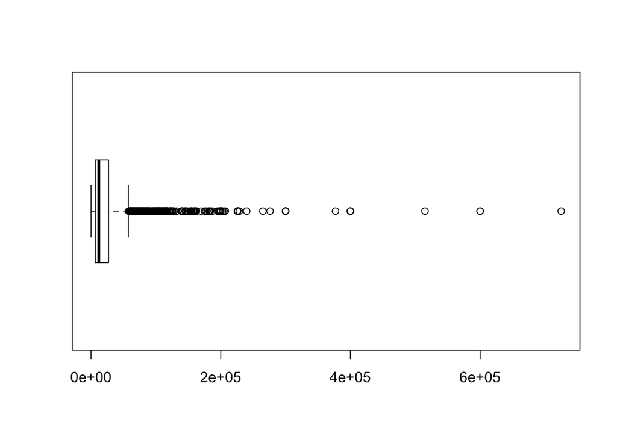

```r
# Instalación (si es necesario) y carga de la librería ggplot2
if(!require(sampling)){
    install.packages('sampling', repos='http://cran.rstudio.com')
    library(sampling)
}
# Instalación (si es necesario) y carga de la librería ggplot2
if(!require(DescTools)){
    install.packages('DescTools', repos='http://cran.rstudio.com')
    library(DescTools)
}
# Detección de outliers en el campo Distancia
info <- boxplot(datos$Distancia, horizontal = TRUE)
```

```r
headers <- c("Outliers", "Total", "% Outliers")
df <- as.data.frame(matrix(NA,ncol=3,nrow=0))
df <- rbind(df, "Distancia" = c(length(info$out), length(datos$Distancia), 100*(length(info$out)/length(datos$Distancia))))
colnames(df)<-headers
df
```

```
##   Outliers Total % Outliers
## 1      408  5550   7.351351
```

Como podemos observar de los 5550 registros tenemos un 7,35% (408 registros) que son outliers. No obstante, hacerlo así no tiene mucho sentido. Una distancia de 200km puede ser un outlier si se trata de una competición de footing, pero puede darse en ciclismo. Por tanto, la forma de analizar los outliers debe ser por tipo de prueba:

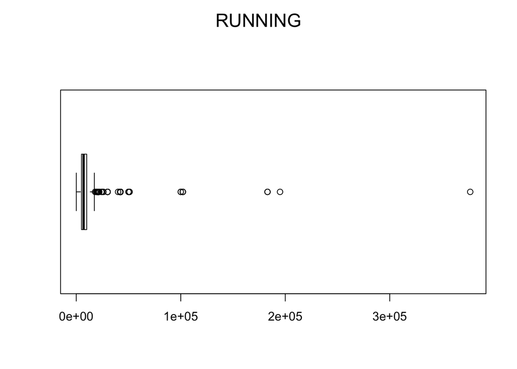

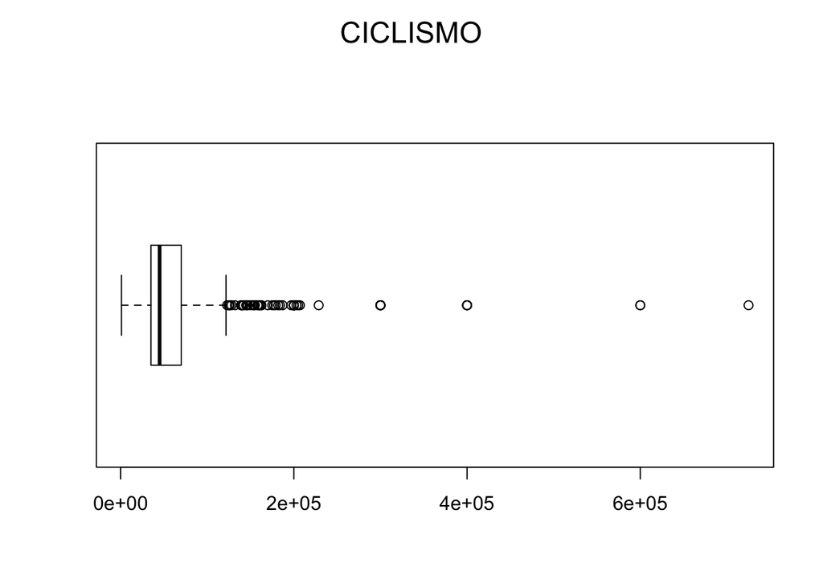

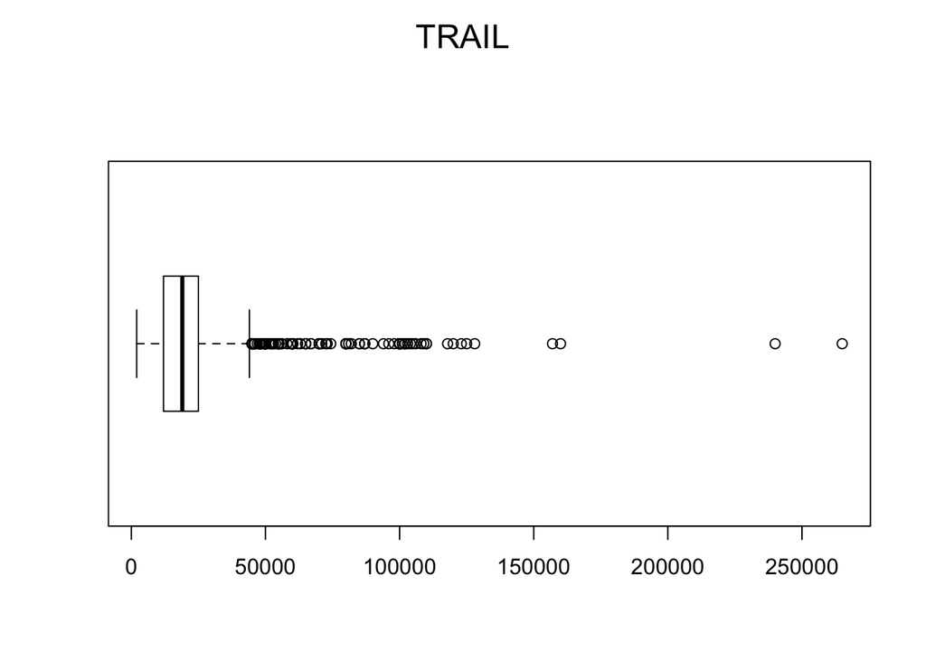

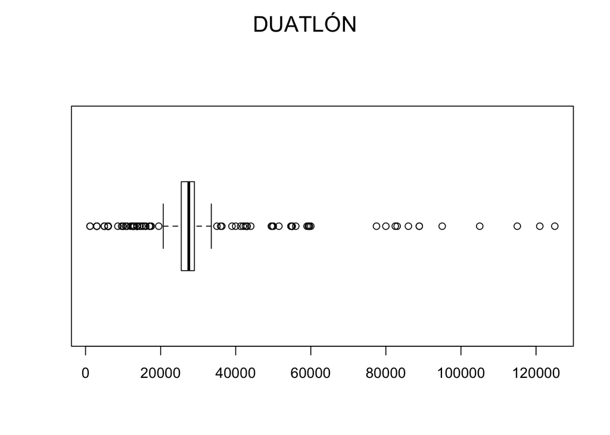

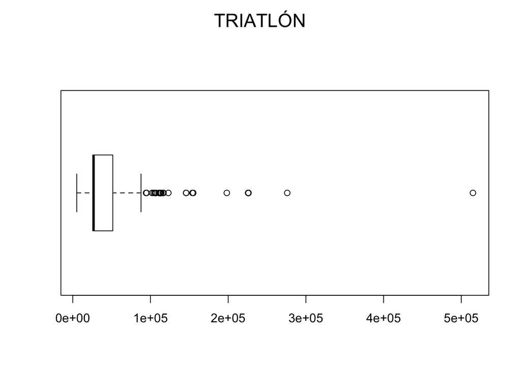

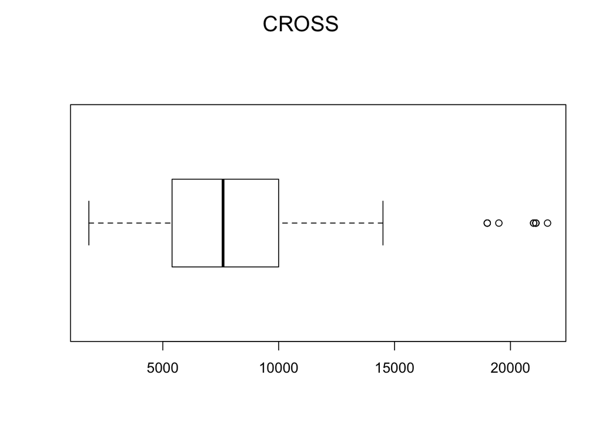

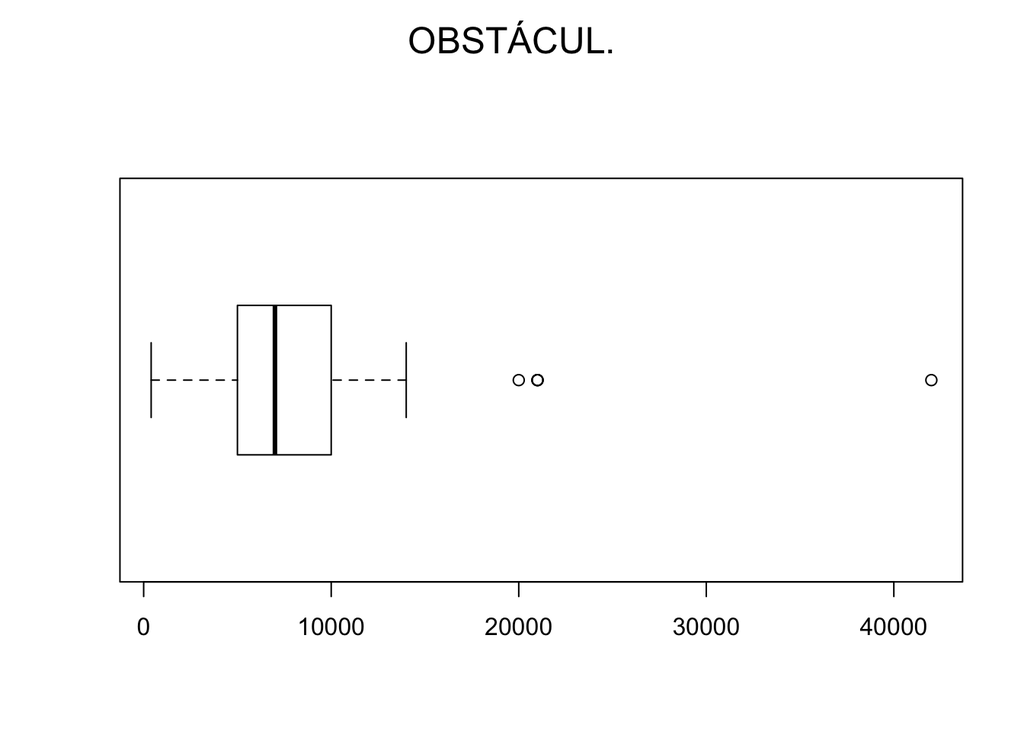

```r
df <- as.data.frame(matrix(NA,ncol=3,nrow=0))

tipos <- c("RUNNING","CICLISMO", "TRAIL", "DUATLÓN", "TRIATLÓN", "CROSS", "OBSTÁCUL.")


for(tipo in tipos) {

  par(oma=c(0,0,2,0))
  sdatos <- subset(datos, Tipo == tipo)
  info <- boxplot(sdatos$Distancia, horizontal = TRUE)
  mtext(tipo, outer=TRUE, cex=1.5)
  df <- rbind(df, tipo = c(length(info$out), length(sdatos$Distancia), 100*(length(info$out)/length(sdatos$Distancia))))

}
```

```r
headers <- c("Outliers", "Total", "% Outliers")
colnames(df)<-headers
rownames(df) = tipos
df <- df[order(-df[,3]),]
df
```

```
##           Outliers Total % Outliers
## DUATLÓN        103   335  30.746269
## TRIATLÓN        64   345  18.550725
## RUNNING        287  2328  12.328179
## CICLISMO        63   668   9.431138
## TRAIL          124  1432   8.659218
## OBSTÁCUL.        5   103   4.854369
## CROSS           10   339   2.949853
```

Como se puede observar en los gráficos y en la tabla anterior de forma númerica, en todos los tipos de carreras tenemos outliers; y principalmente en los tipos de carrera Duatlón y Triatlón con un 30,75% y un 18,55% de outliers respectivamente. Algo menos encontramos en Running, Ciclismo y Trail aunque con valores bastante significativos. La duda es de si son realmente outliers o se trata de pruebas muy extremas.

Por último, en Obstáculos y cross prácticamente no tenemos outliers.

# 4 Análisis de los datos

## 4.1 Selección de los grupos de datos

Los atributos que se utilizarán en el estudio son los indicados anteriormente: Estación, Provincia, Tipo, Distancia e Infantil. Son los parámetros fundamentales de las pruebas deportivas:

- En qué estación del año se celebran.
- Dónde se celebran. Se utilizará el dato disponible, que es la provincia. Pudiera ser interesante hacer una agrupación por comunidades autónomas. También hay que tener en cuenta que, después de la limpieza de datos, además de las provincias españolas hay una categoría adicional “resto del mundo”. Esta categoría incluye todas las pruebas anunciadas en la web utilizada en el estudio y que no se celebran en España.
- Tipo de prueba que se celebra.
- Distancia de la prueba.
- La prueba dispone de categoría infantil..

**Es decir, los atributos seleccionados representan la información del cuándo (Estacion), dónde (Provincia), qué (Tipo), cuánto (Distancia), quién (Adultos o Infantil y Adultos), que son las cuestiones básicas respecto a cualquier problema.**

Los estudios que se plantea realizar son los indicados anteriormente:

- Detección de las **reglas de asociación** entre mes de la prueba, provincia de la prueba, tipo de carrera, distancia y si es infantil o no.
- Detección de grupos mediante **técnicas de clustering** para los campos anteriores.
- Estudio de **regresión múltiple**.

## 4.2 Comprobación de la normalidad y homogenidad de la varianza

En este apartado realizaremos tests de normalidad y homocedasticidadaal atributo distancia para determinar que pruebas estadísticas debemos aplicar en la fase de análisi. Ejecutamos el test de Kolmogorov-Smirnov sobre el atributo distancia, que a pesar de lanzar un warning, nos indica que debemos rechazar la hipotesis nula y asumir que no sigue una distribución normal.

### 4.2.1 Test de normalidad del atributo Distancia

```r
ks.test(datos$Distancia, pnorm, mean(datos$Distancia), sd(datos$Distancia))
```

```
## Warning in ks.test(datos$Distancia, pnorm, mean(datos$Distancia),
## sd(datos$Distancia)): ties should not be present for the Kolmogorov-Smirnov
## test
```

```
##
##  One-sample Kolmogorov-Smirnov test
##
## data:  datos$Distancia
## D = 0.26313, p-value < 2.2e-16
## alternative hypothesis: two-sided
```

Realizamos también el test Shapiro-Wilk, más robusto que el anterior, para comprobar si sigue una distribución normal. Previamente, para poder realizar el test debemos seleccionar una muestra más pequeña, cosa que haremos cogiendo una muestra aleatoria simple sin sustitución (SRSWOR).

```r
s=srswor(5000, length(datos$Distancia))

shapiro.test(as.vector(datos$Distancia[s==1]))
```

```
##
##  Shapiro-Wilk normality test
##
## data:  as.vector(datos$Distancia[s == 1])
## W = 0.486, p-value < 2.2e-16
```

Y como se comprueba por el valor d p-value confirmamos que los datos no siguen una distribución normal.

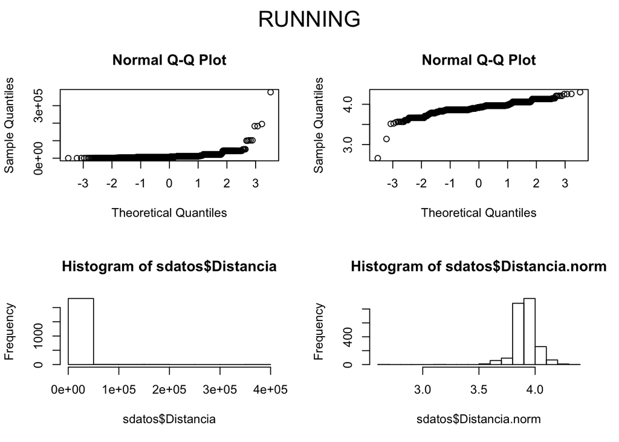

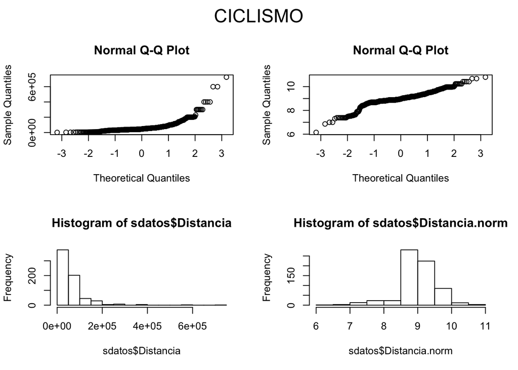

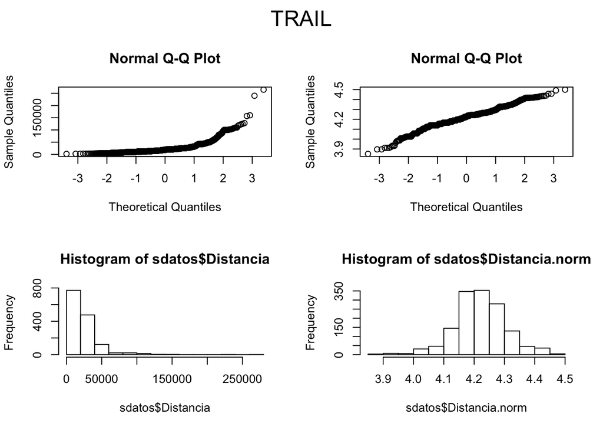

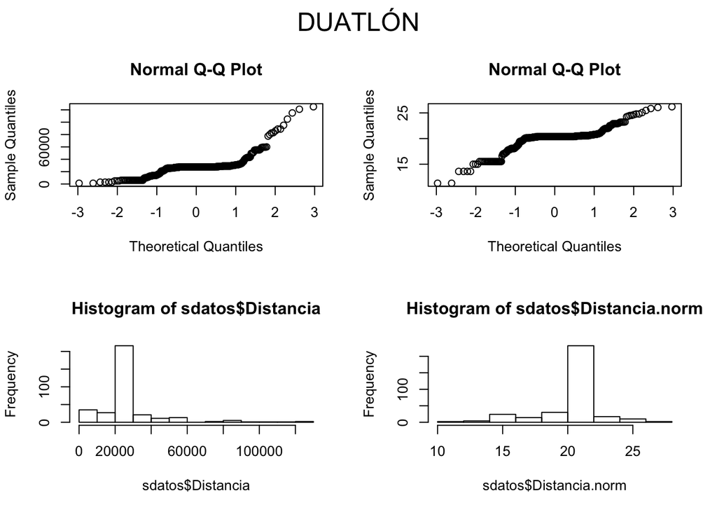

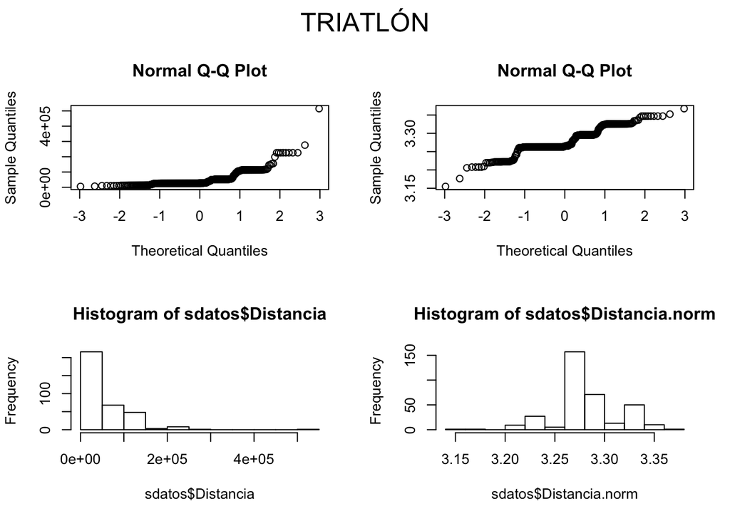

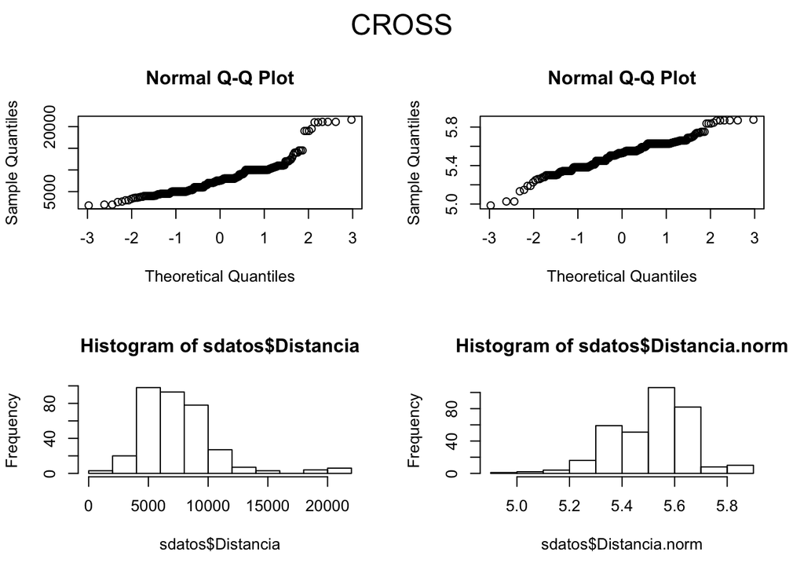

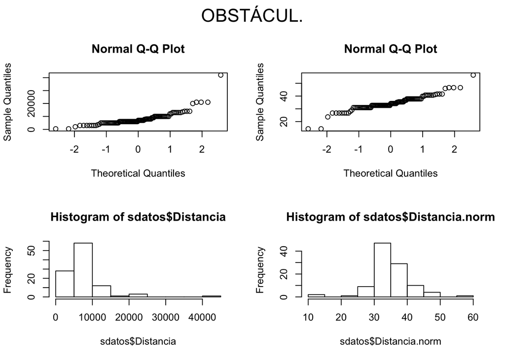

```r
# Instalación (si es necesario) y carga de la librería ggplot2
if(!require(sampling)){
    install.packages('sampling', repos='http://cran.rstudio.com')
    library(sampling)
}
# Instalación (si es necesario) y carga de la librería ggplot2
if(!require(DescTools)){
    install.packages('DescTools', repos='http://cran.rstudio.com')
    library(DescTools)
}

statsTipo <- vector()

for(tipo in c("RUNNING","CICLISMO", "TRAIL", "DUATLÓN", "TRIATLÓN", "CROSS", "OBSTÁCUL.")) {
  sdatos <- subset(datos, Tipo == tipo)
  invisible(stats <- shapiro.test(sdatos$Distancia))

  statsTipo[tipo] <- stats$p.value

  sdatos$Distancia.norm <- BoxCox(sdatos$Distancia, lambda = BoxCoxLambda(sdatos$Distancia))
  par(mfrow=c(2,2), oma=c(0,0,2,0))
  qqnorm(sdatos$Distancia)
  qqnorm(sdatos$Distancia.norm)
  hist(sdatos$Distancia)
  hist(sdatos$Distancia.norm)
  mtext(tipo, outer=TRUE, cex=1.5)

}
```

Para cada tipo de carrera creamos un subconjunto de los datos, normalizamos la distáncia y generamos los gráficos Q-Q y los histogramas de los datos sin normalizar (izquierda) y los datos normalizados (derecha). Visualmente es fácil comprobar como los datos de distancia no siguen una distribución normal y confirmamos los resultados obtenidos con los tests anteriores.

```r
statsTipo
```

```
##      RUNNING     CICLISMO        TRAIL      DUATLÓN     TRIATLÓN
## 1.674836e-67 6.602895e-37 3.483012e-47 3.494524e-24 2.748384e-26
##        CROSS    OBSTÁCUL.
## 6.570259e-16 3.389858e-12
```

Númericamente vemos como los valores de p-value para el test shapiro-Wilk de cada subconjunto de datos por tipo de carrera nos indica que ningún conjunto cumple la distribución de normalidad.

Para comprobar la homocedasticidad en los datos, aplicamos el test Fligner-Killeen puesto que los datos no siguen una distribución normal. Y el resultado obtenido nos indica que a distancia presenta varianzas estadísticamente diferentes para los diferentes grupos.

```r
# Instalación (si es necesario) y carga de la librería ggplot2
if(!require(sampling)){
    install.packages('sampling', repos='http://cran.rstudio.com')
    library(sampling)
}
# Instalación (si es necesario) y carga de la librería ggplot2
if(!require(DescTools)){
    install.packages('DescTools', repos='http://cran.rstudio.com')
    library(DescTools)
}

# Detección de outliers en el campo Distancia
datos$Distancia.norm <- BoxCox(datos$Distancia, lambda = BoxCoxLambda(datos$Distancia))
fligner.test(Distancia.norm ~ Tipo, data = datos)
```

```
##
##  Fligner-Killeen test of homogeneity of variances
##
## data:  Distancia.norm by Tipo
## Fligner-Killeen:med chi-squared = 234.72, df = 6, p-value <
## 2.2e-16
```

Una vez determinado que la distáncia no sigue una distribución normal ni presenta homocedasticidad, aplicamos el test de kruskal (no paramétrico) para comparar la distancia en función del tipo de carrera y obtenemos como resultado que la distància muestra diferencias significativas en función del tipo de carrera.

```r
# Test Kruskal
kruskal.test(Distancia ~ Tipo, data = datos)
```

```
##
##  Kruskal-Wallis rank sum test
##
## data:  Distancia by Tipo
## Kruskal-Wallis chi-squared = 3012.2, df = 6, p-value < 2.2e-16
```

## 4.3 Aplicación de pruebas

### 4.3.1 Reglas de asociación

En este punto se utilizará el algoritmo *apriori* para obtener las reglas de asociación del conjunto de datos. Para ello hay que convertir la variable numérica distancia en un factor. Para ello se creará una nueva columna, llamada DistanciaF, en la que se categorizará la distancia de la siguiente forma:

- CORTA: $\leqslant$ 1km.
- MEDIA: $>$ 1km y $\leqslant$ 5km.
- LARGA: $>$ 5km y $\leqslant$ 20km.
- FONDO: $>$ 20km y $\leqslant$ 50km.
- GRAN FONDO: $>$ 50km y $\leqslant$ 100km.
- ULTRAMARATÓN: $>$ 100km.

```r
datos$DistanciaF <-cut (datos[["Distancia"]], breaks=c(0, 1000, 5000, 20000, 50000, 100000, 1000000), labels=c("CORTA", "MEDIA", "LARGA", "FONDO", "GRAN FONDO", "ULTRAMARATON"))
table(datos$DistanciaF)
```

```
##
##        CORTA        MEDIA        LARGA        FONDO   GRAN FONDO
##           14          994         2397         1600          360
## ULTRAMARATON
##          185
```

En la tabla anterior se muestra el número de pruebas de cada categoría.

```r
# Instalación (si es necesario) y carga de la librería arules
if(!require(arules)){
    install.packages('arules', repos='http://cran.rstudio.com')
    library(arules)
}
# Instalación (si es necesario) y carga de la librería dplyr
if(!require(dplyr)){
    install.packages('dplyr', repos='http://cran.rstudio.com')
    library(dplyr)
}
# Se ejecuta el modelo apriori en las columnas seleccionadas.
rules <- apriori(select(datos, Estacion, Provincia, Tipo, DistanciaF, Infantil), parameter = list(supp = 0.01, conf = 0.85))
```

```
## Apriori
##
## Parameter specification:
##  confidence minval smax arem  aval originalSupport maxtime support minlen
##        0.85    0.1    1 none FALSE            TRUE       5    0.01      1
##  maxlen target   ext
##      10  rules FALSE
##
## Algorithmic control:
##  filter tree heap memopt load sort verbose
##     0.1 TRUE TRUE  FALSE TRUE    2    TRUE
##
## Absolute minimum support count: 55
##
## set item appearances ...[0 item(s)] done [0.00s].
## set transactions ...[72 item(s), 5550 transaction(s)] done [0.00s].
## sorting and recoding items ... [62 item(s)] done [0.00s].
## creating transaction tree ... done [0.00s].
## checking subsets of size 1 2 3 4 done [0.00s].
## writing ... [46 rule(s)] done [0.00s].
## creating S4 object  ... done [0.00s].
```

A continuación, se ordenan las reglas y se muestran las primeras:

```r
# Se ordenan las reglas.
rules <- sort(rules, by="confidence", decreasing=TRUE)

# Se muestran las reglas.
inspect(rules, ruleSep = "---->", itemSep = " + ", setStart = "", setEnd ="", linebreak = FALSE)
```

```
##      lhs
## [1]  Provincia=VALENCIA + DistanciaF=MEDIA                     ---->
## [2]  Estacion=SPRING + Tipo=CICLISMO + DistanciaF=ULTRAMARATON ---->
## [3]  Estacion=SPRING + Tipo=CICLISMO + DistanciaF=GRAN FONDO   ---->
## [4]  Provincia=VALENCIA + DistanciaF=MEDIA + Infantil=TRUE     ---->
## [5]  Tipo=CICLISMO + DistanciaF=GRAN FONDO                     ---->
## [6]  Estacion=SPRING + DistanciaF=ULTRAMARATON                 ---->
## [7]  Tipo=CICLISMO + DistanciaF=ULTRAMARATON                   ---->
## [8]  Estacion=FALL + Tipo=CICLISMO                             ---->
## [9]  Estacion=WINTER + Tipo=CICLISMO + DistanciaF=GRAN FONDO   ---->
## [10] Estacion=SPRING + Tipo=CICLISMO                           ---->
## [11] Estacion=WINTER + DistanciaF=GRAN FONDO                   ---->
## [12] Estacion=SUMMER + Tipo=CICLISMO                           ---->
## [13] DistanciaF=ULTRAMARATON                                   ---->
## [14] Tipo=CICLISMO                                             ---->
```

[output cut: 79 more lines]

Como se ve de los datos mostrados, se han encontrado 46 reglas. Por ejemplo, la primera regla es “Si la provincia es VALENCIA y la distancia es MEDIA (entre 1 y 5 km), entonces el tipo de carrera es RUNNING”.

### 4.3.2 Árboles de decisión

El siguiente estudio a realizar también tiene que ver con la clasificación, y para ello se utilizarán árboles de decisión. Los datos ya se encuentran en el formato adecuado para ello, pues todas las variables que que utilizarán están factorizadas. En este caso se utilizarán las mismas variables del punto anterior.

Lo primero que hay que realizar es dividir el dataset en dos subconjuntos, uno de test y otro de training. El conjunto de entrenamiento tendrá 2/3 de los registros, y el de test tendrá el tercio restante. En primer lugar hay que desordenar los registros:

```r
# Se desordenan los registros
set.seed(666)
# A continuación, se desordenan los datos.
datos_random <- datos[sample(nrow(datos)),]
```

El siguiente paso es crear el conjunto de entrenamiento y el de prueba. La clasificación se hará por la columna DistanciaF.

```r
# Se inicializa la semilla
set.seed(23542)
# Se crean dos nuevas columnas: ProvinciaSA y TipoSA, suprimiendo los acentos para que el algoritmo C50 no tenga problemas
datos_random$ProvinciaSA <- as.factor(iconv(Provincia, "UTF-8", "ASCII//TRANSLIT"))
datos_random$TipoSA <- as.factor(iconv(Tipo, "UTF-8", "ASCII//TRANSLIT"))
# Se utiliza la columna Distancia para la calsificación.
cy <- as.factor(datos_random[,11])
# Se seleccionan las otras tres columnas.
cX <- select(datos_random, Estacion, TipoSA, ProvinciaSA, Infantil)

# Se dividen los dos conjuntos
ind = sample(1:nrow(datos_random), size=floor((2/3)*nrow(datos_random)))
entrenX<-cX[ind,]
entreny<-cy[ind]
pruebaX<-cX[-ind,]
pruebay<-cy[-ind]
```

A continuación, se genera el modelo utilizando el algoritmo C5.0:

```r
# Instalación (si es necesario) y carga de la librería C50
if(!require(C50)){
    install.packages('C50', repos='http://cran.rstudio.com')
    library(C50)
}
modelo <- C5.0(entrenX, entreny, rules=TRUE )
summary(modelo)
```

```
##
## Call:
## C5.0.default(x = entrenX, y = entreny, rules = TRUE)
##
##
## C5.0 [Release 2.07 GPL Edition]      Sun Jun  9 16:15:23 2019
## -------------------------------
##
## Class specified by attribute `outcome'
##
## Read 3700 cases (5 attributes) from undefined.data
##
## Rules:
##
## Rule 1: (12/5, lift 3.1)
##  Estacion = WINTER
##  TipoSA = Ciclismo
##  ProvinciaSA = Barcelona
##  Infantil = TRUE
##  ->  class MEDIA  [0.571]
##
## Rule 2: (11/6, lift 2.5)
##  TipoSA in {Running, Trail}
##  ProvinciaSA = Portugal
##  ->  class MEDIA  [0.462]
##
## Rule 3: (1600/1210, lift 1.3)
##  Estacion = WINTER
##  ->  class MEDIA  [0.244]
##
## Rule 4: (7/1, lift 1.8)
##  Estacion = SPRING
##  TipoSA in {Running, Trail, Triatl'on}
##  ProvinciaSA = Valladolid
##  Infantil = TRUE
##  ->  class LARGA  [0.778]
##
## Rule 5: (34/9, lift 1.7)
##  TipoSA in {Cross, Duatl'on, Triatl'on}
##  ProvinciaSA = Barcelona
```

[output cut: 150 more lines]

```
##             4  1012   544     3          (c): class LARGA
##             2   395   705     3          (d): class FONDO
##             2    58   160    11          (e): class GRAN FONDO
##             1    29    89                (f): class ULTRAMARATON
##
##
##  Attribute usage:
##
##  100.00% Infantil
##   57.30% Estacion
##   32.19% ProvinciaSA
##   16.24% TipoSA
##
##
## Time: 0.0 secs
```

Como se ve en los resultados mostrados, el algoritmo encuentra 28 reglas. Por ejemplo, la primera regla es “Si la estación es invierno, el tipo es Ciclismo, la provincia es Barcelona y es una prueba Infantil, entonces hay un 57% de probabilidad de que la distancia sea media”.

### 4.3.3 Regresión Múltiple

```r
regmod <- (lm(Distancia ~ Tipo + Estacion + Infantil, data = datos))
summary(regmod)
```

```
##
## Call:
## lm(formula = Distancia ~ Tipo + Estacion + Infantil, data = datos)
##
## Residuals:
##    Min     1Q Median     3Q    Max
## -66294  -8521  -2326   2291 663160
##
## Coefficients:
##               Estimate Std. Error t value Pr(>|t|)
## (Intercept)    58782.3     1509.6  38.938  < 2e-16 ***
## TipoCROSS     -52965.6     2070.3 -25.584  < 2e-16 ***
## TipoDUATLÓN   -34605.7     2011.8 -17.202  < 2e-16 ***
## TipoOBSTÁCUL. -55138.1     3177.9 -17.351  < 2e-16 ***
## TipoRUNNING   -51752.7     1395.0 -37.100  < 2e-16 ***
## TipoTRAIL     -40620.7     1403.7 -28.938  < 2e-16 ***
## TipoTRIATLÓN  -12412.1     2018.2  -6.150 8.29e-10 ***
## Estacion.L     -2310.9      754.5  -3.063   0.0022 **
## Estacion.Q      1779.7     1067.2   1.668   0.0954 .
## Estacion.C     -2952.7     1293.5  -2.283   0.0225 *
## InfantilTRUE    5411.4      947.3   5.712 1.17e-08 ***
## ---
## Signif. codes:  0 '***' 0.001 '**' 0.01 '*' 0.05 '.' 0.1 ' ' 1
##
## Residual standard error: 29770 on 5539 degrees of freedom
## Multiple R-squared:  0.2908, Adjusted R-squared:  0.2895
## F-statistic: 227.1 on 10 and 5539 DF,  p-value: < 2.2e-16
```

De los datos obtenidos se deduce que el tipo de prueba y la categoría (infantil o adulto) están fuertemente correlacionadas con la Distancia. La estación también lo está, pero en menor grado.

Por otro lado, el valor de $R^2$ es 0,2908. Esto quiere decir que el modelo explica el 29% de la variabilidad de la variable Distancia.

#### 4.3.3.1 Grabación del fichero

Se genera el fichero runnings_clean.csv, que incluye los procesos de limpieza y las variables generadas.

```r
# Se graba el fichero runnings_clean.csv
write.csv(datos, file="../csv/runnings_clean.csv")
```

# 5 Representación Gráfica

En este apartado se mostrarán diferentes gráficos para una mejor comprensión de los datos.

## 5.1 Gráficos de tartas

### 5.1.1 Pruebas por Estación

A continuación se muestra la tarta de pruebas por estación:

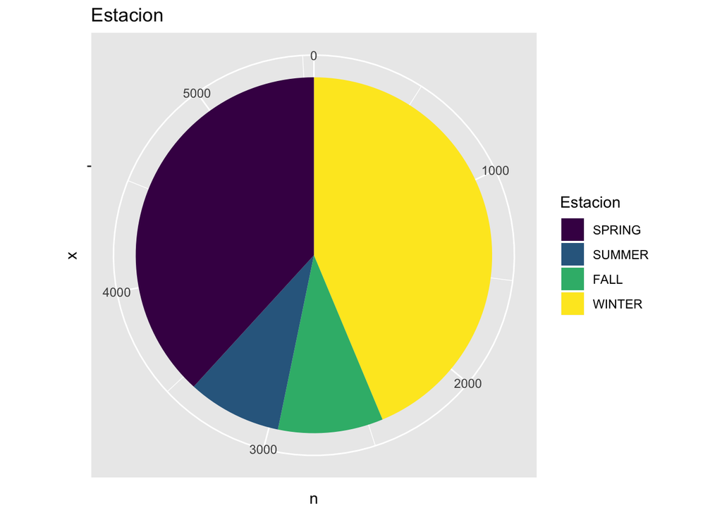

```r
# Instalación (si es necesario) y carga de la librería ggplot2
if(!require(ggplot2)){
    install.packages('ggplot2', repos='http://cran.rstudio.com')
    library(ggplot2)
}
# Se representa la tarta de pruebas por estación.
Estacionsum <- summarize( group_by(datos, Estacion), n=length(Estacion))
ggplot(Estacionsum, aes(x="", y=n, fill=Estacion)) +
  geom_bar(width = 1, stat = "identity") +
    coord_polar("y", start=0) + ggtitle("Estacion")
```

### 5.1.2 Pruebas por Tipo

A continuación se muestra la tarta de pruebas por tipo:

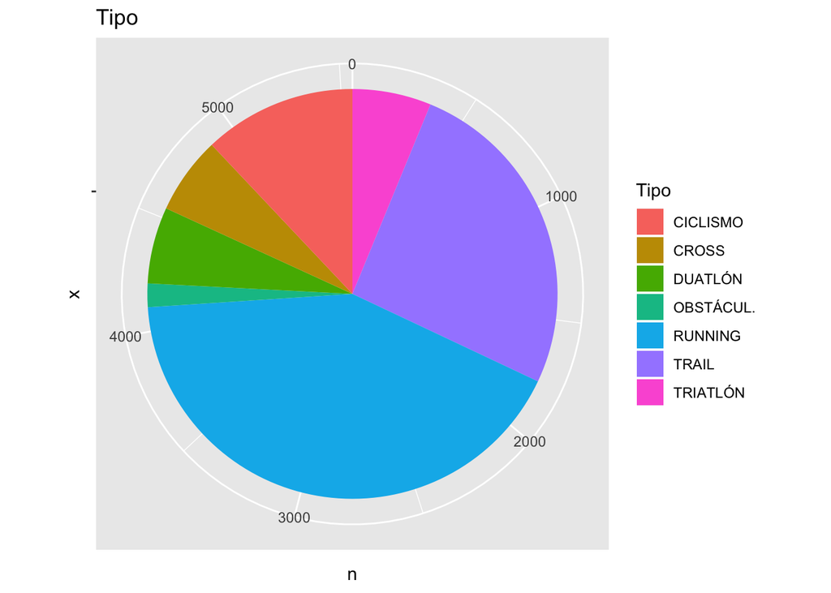

```r
# Se representa la tarta de pruebas por tipo.
Tiposum <- summarize( group_by(datos, Tipo), n=length(Tipo))
ggplot(Tiposum, aes(x="", y=n, fill=Tipo)) +
  geom_bar(width = 1, stat = "identity") +
    coord_polar("y", start=0) + ggtitle("Tipo")
```

### 5.1.3 Pruebas por Categoría (Infantil o Adulto)

A continuación se muestra la tarta de pruebas por la categoría, Infantil o Adulto:

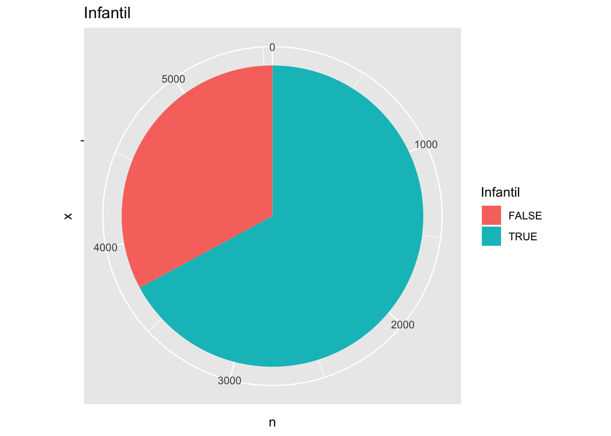

```r
# Se representa la tarta de pruebas por categprçoa.
Infantilsum <- summarize( group_by(datos, Infantil), n=length(Infantil))
ggplot(Infantilsum, aes(x="", y=n, fill=Infantil)) +
  geom_bar(width = 1, stat = "identity") +
    coord_polar("y", start=0) + ggtitle("Infantil")
```

## 5.2 Diagramas de barras

## 5.3 Diagrama de pruebas por Tipo y distancia

En el diagrama siguiente se muestran las pruebas que se celebran de cada tipo, diferenciando según la distáncia categorizada. En este caso, hay dos conclusiones obvias. La primera es que los dos tipos mayoritarios son running y trail. La segunda es que hay categorías de distancia en que apenas se celebran carreras como la distancia CORTA.

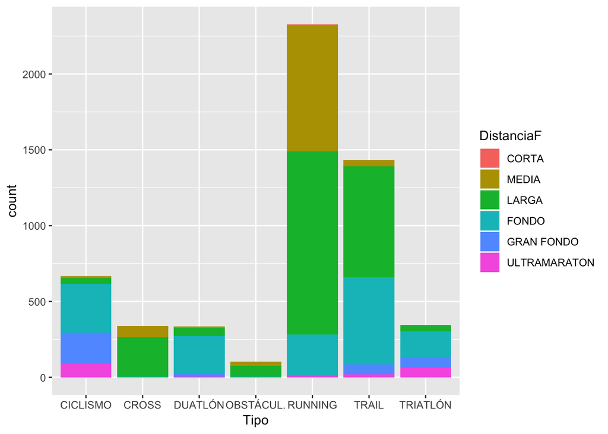

```r
# Se representa el diagrama por estación y categoría
ggplot(data=datos[1:dim(datos)[1],],aes(x=Tipo, fill=DistanciaF))+geom_bar()
```

## 5.4 Diagrama de pruebas por tipo y estación

En el diagrama siguiente se muestran las pruebas que se celebran de cada tipo diferenciando según la estación. Es fácil extraer la conclusión que los seis meses correspondientes a la primavera y el invierno son los que concentran el mayor número de pruebas.

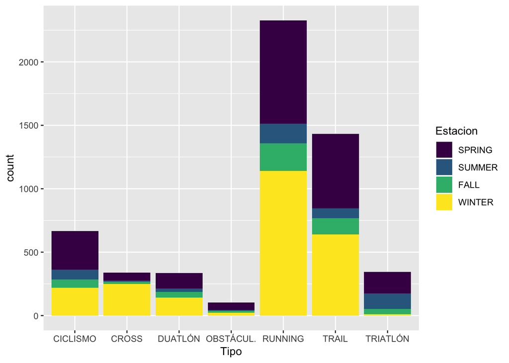

```r
# Se representa el diagrama por tipo y categoría
ggplot(data=datos[1:dim(datos)[1],],aes(x=Tipo, fill=Estacion))+geom_bar()
```

# 6 Conclusiones

Del análisis realizado se extraen las siguientes conclusiones:

- La mayoría de las pruebas se concentran en primavera e invierno, mientras que en verano y otoño se celebran muy pocas. En concreto, en los seis mese correspondientes a primavera e invierno se celebran cinco veces más pruebas que en verano y otoño: el 82% de las pruebas se celebran en los seis meses de primavera e invierno.
- El dataset se ha obtenido de una página que se limita a publicitar qué pruebas se celebran. Sería interesante que el dataset incluyera el dato de número de inscritos, que permitiría obtener muchas más conclusiones.
- Otro dato interesante a incorporar al dataser sería el de la población por provincia, para poder analizar su correlación con la celebración de pruebas. Es intuitivo pensar que sí deberían estar correlacionados, pero se han detectado casos que llaman la atención. Por ejemplo, en Valencia se celebran casi las mismas pruebas que en Madrid y muchas más que en Barcelona, que tiene mayor población y un clima similar.
- El tipo de prueba mayoritaria es *running*, que se corresponde con la actividad física básica, y la segunda es *trail*, es decir, *running* campo a través. Entre ambas categorías suman casi el 70% de las pruebas.
- Las variables Tipo, Distancia, Estación e Infantil están correlacionadas.
- Las pruebas más duras (ciclismo, *trail* y triatlón) no se suelen celebrar en categoría infantil.

# 7 Contribuciones

| Contribuciones | Firma |
| --- | --- |
| Investigación Previa | ECS - ARFR |
| Redacción de las Respuestas | ECS - ARFR |
| Desarrollo Código | ECS - ARFR |